# Lab_07R

36-290 – Statistical Research Methodology

Week 7 Thursday – Fall 2020

Name: Cherie Hua

Andrew ID: cxhua

This lab is to be begun in class, but may be finished outside of class at any time prior to Friday, October 16<sup>th</sup> at 6:00 PM. You must commit both the edited `Rmd` file and the “knitted” `html` file for this lab to your `GitHub` repo. (You can verbally discuss aspects of the labs with your classmates, but please do not share code, etc.)

# Preliminaries

## Goal

Today you will largely follow the script of Tuesday’s lab, while applying random forest in place of classification and regression trees.

# Data, Part I

Below we read in the same data that we used on Monday, except that we downsample the data to have sizes 10000 (train) and 5000 (test) to keep computation time manageable. (Random forest takes time because you generate 500 trees by default.)

```r
rm(list=ls())
file.path = "https://raw.githubusercontent.com/pefreeman/36-290/master/EXAMPLE_DATASETS/DM_GALAXY/Massive_Black_II.Rdata"
load(url(file.path))
rm(file.path)
objects()
```

```
## [1] "pred.test"     "pred.train"    "resp.test.df"  "resp.train.df"
```

```r
resp.train = resp.train.df$prop.sfr
w = which(resp.train>0)
pred.train = pred.train[w,]
resp.train = log10(resp.train[w])

resp.test  = resp.test.df$prop.sfr
w = which(resp.test>0)
pred.test = pred.test[w,]
resp.test = log10(resp.test[w])

set.seed(202)
s = sample(length(resp.train),10000)
pred.train = pred.train[s,]
resp.train = resp.train[s]
s = sample(length(resp.test),5000)
pred.test = pred.test[s,]
resp.test = resp.test[s]

cat("Sample sizes: train = ",length(resp.train)," test = ",length(resp.test),"\n")
```

```
## Sample sizes: train =  10000  test =  5000
```

# Questions

## Question 1

Because we reduced the sample size relative to that in Tuesday’s lab, re-determine the test-set MSE for a linear regression model and then determine the test-set MSE for a random forest model. (In the argument list for `randomForest`, set `importance=TRUE`) Also display the predicted response versus observed response diagnostic plot (with the same limits on each axis!). Did the test-set MSE improve by using random forest? (Note: for reproducible results, set the seed before running random forest!)

```r
#find mse
set.seed(14983)
lm.train = lm(resp.train ~ ., data = pred.train)
lm.preds = predict(lm.train, newdata = pred.test)
lm.mse = mean((resp.test - lm.preds)^2)
lm.mse
```

```
## [1] 0.2503715
```

```r
set.seed(95873)
library(randomForest)
library(GGally)
rf <- randomForest(formula = resp.train ~ ., data = pred.train, importance = TRUE)
yhat.rf = predict(rf, newdata = pred.test)
rf.mse = mean((yhat.rf - resp.test)^2)
rf.mse
```

```
## [1] 0.232325
```

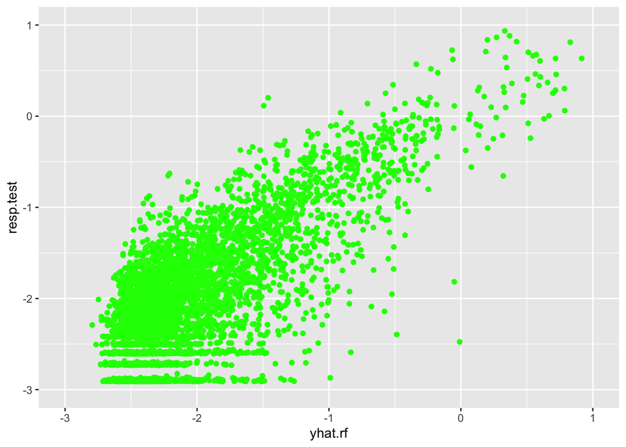

```
The random forest model slightly improved the MSE.
```

```r
ggplot(mapping = aes(yhat.rf, resp.test)) + geom_point(color = "green") + ylim(-3, 1) + xlim(-3, 1)
```

## Question 2

Create a variable importance plot for random forest. (See page 330 of ISLR.) You can subdivide the predictor variables into groups: those that reference dark matter particle velocity (ones with “v”), mass (“m”), or radius from the halo center (“r”), along with those that reference the gravitational potential (the ones with angle variables) and the shape of the halo (“shapes”). Do some inference: what is the most important property of a halo with regard to predicting star-formation rate? How about the least important?

```r
importance(rf)
```

```
##                %IncMSE IncNodePurity
## halos.vdisp  42.696958     1680.4133
## halos.vcirc  35.399394     1298.9567
## halos.rcirc  42.587696      512.9936
## halos.m_dm   36.948469      926.5699
## r_parent     32.883954      317.0396
## shapesDM.q3d 26.209691      242.9314
## shapesDM.s3d 17.831244      234.2227
## thetaTid      2.396633      221.0871
## phiTid       -1.253537      218.0450
```

[output not shown]

Now we turn our attention to classification.

# Data, Part II

We will now load the second dataset from Monday, but we will do two things: (1) cut down the sample size to get random forest to run faster, and (2) balance the classes.

```r
rm(list=ls())
file.path = "https://raw.githubusercontent.com/pefreeman/36-290/master/EXAMPLE_DATASETS/TD_CLASS/css_data.Rdata"
load(url(file.path))
rm(file.path)
objects()
```

```
## [1] "predictors" "response"
```

```r
# Eliminate the max.slope column (the 11th column), which has infinities.
predictors = predictors[,-11]

# Cut the CB and NON-CB class sizes to 5000 samples each.
set.seed(303)
w = which(response==1)
s = sample(length(w),5000)
predictors.cb = predictors[w[s],]
response.cb   = response[w[s]]
w = which(response!=1)
s = sample(length(w),5000)
predictors.noncb = predictors[w[s],]
response.noncb   = response[w[s]]
predictors = rbind(predictors.cb,predictors.noncb)
response   = c(response.cb,response.noncb)

response.new = rep("CB",length(response))
w = which(response!=1)
response.new[w] = "NON-CB"
response = factor(response.new)
```

# Questions

## Question 3

You know the drill: split the data (or do CV if you are feeling adventurous), then learn a logistic regression model and output the test-set MCR value and the confusion matrix. Then learn a random forest model, output the variable importance plot and the test-set MCR value and the confusion matrix. Compare and contrast the results: would you use the logistic regression model or the random forest model? As for variable importance: when using a tree, flux.mid35, mad, and skew tended to be important predictors. Is that result consistent with what you observe here? (Note: for logistic regression, `predict()` with `type=“response”` gives you numbers you need to round off, whereas for random forest, you’ll get actual CB vs. NON-CB predictions. Sigh. Inconsistency is not a virtue.)

```r
#sample
set.seed(45)
s = sample(nrow(predictors), 0.7*nrow(predictors))
pred.train = predictors[s,]
resp.train = response[s]

pred.test = predictors[-s,]
resp.test = response[-s]

#lin reg
set.seed(385)
glm.train = glm(resp.train ~ ., data = pred.train, family = "binomial")
glm.preds = predict(glm.train, newdata = pred.test, type = "response")
table(ifelse(glm.preds < 0.5, "CB", "NON-CB"), resp.test)
```

```
##         resp.test
##            CB NON-CB
##   CB     1164    478
##   NON-CB  350   1008
```

```r
(350 + 478)/(1164 + 1008)
```

```
## [1] 0.3812155
```

```r
#random forest
library(randomForest)
rf <- randomForest(formula = resp.train ~ ., data = pred.train, importance = TRUE)
yhat.rf = predict(rf, newdata = pred.test)
table(yhat.rf, resp.test)
```

```
##         resp.test
## yhat.rf    CB NON-CB
##   CB     1284    359
##   NON-CB  230   1127
```

```r
#mcr
(230 + 359)/(1284 + 1127)
```

```
## [1] 0.244297
```

```r
importance(rf)
```

```
##                    CB     NON-CB MeanDecreaseAccuracy MeanDecreaseGini
## amp          23.67512 17.3972069             33.83195         145.0386
## beyond.std   29.85672 15.7026374             30.92794         172.3260
## flux.mid20   42.09827 22.8429545             42.08546         280.9216
## flux.mid35   32.75637 22.6947101             37.79746         292.0028
## flux.mid50   30.56045 17.1937928             34.71403         252.5680
## flux.mid65   29.01859 13.1665564             32.95436         200.0128
## flux.mid80   24.31143 21.3259697             34.88925         158.9242
## kurt         47.74333 19.4708627             52.99813         185.2222
## linear.trend 18.91274  0.4003998             15.92258         128.3649
## mad          37.20771 32.1941525             55.49364         343.0344
## mean         34.42094 15.2306247             42.24781         170.7136
## med.buff     31.21681 22.2611306             41.04976         156.0381
## per.amp      30.14852 13.4371866             38.69142         134.4047
## per.diff     36.55884 24.2240444             50.85116         248.4867
## skew         62.93575 70.6291258             97.87500         434.8744
## std          33.63326 18.3450030             42.11357         196.5083
```

[output not shown]

## Question 4

Install and load the `pROC` package, and plot ROC curves for both logistic regression and random forest. (Google the documentation for the `pROC` package to see how to do this; basically, call the `roc()` function and pass its output to `plot()`. In order to put both curves on the same plot: call `plot()` once, then call `plot()` again with the argument `add=TRUE`. This adds a curve to an existing plot. Also, to tell the curves apart: make them different colors. If you want to be adventurous: add a `legend()`.) For logistic regression, use the class probabilities that you get by calling `predict()` with `type=“response”`, whereas for random forest, call `predict()` with `type=“prob”`, *then* extract the *second* column. Which model has the best AUC? (Try examining the output from `roc()` to determine this. Remember `names()`?)

```r
library(pROC)
glm.roc <- roc(resp.test, glm.preds)
rf.roc <- roc(resp.test, predict(rf, newdata = pred.test, type = "prob")[,2])
```

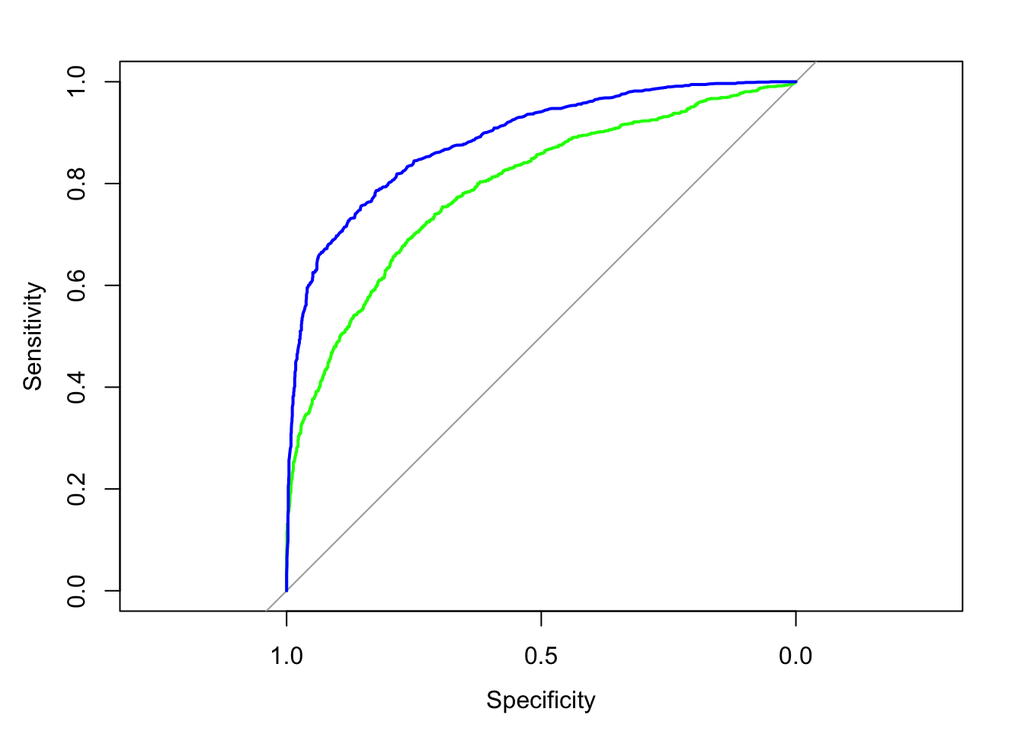

```r
plot(glm.roc, col = "green")
plot(rf.roc, add = TRUE, col = "blue")
```

```r
#green = linear regression
#blue = random forest
glm.roc
```

```
##
## Call:
## roc.default(response = resp.test, predictor = glm.preds)
##
## Data: glm.preds in 1514 controls (resp.test CB) < 1486 cases (resp.test NON-CB).
## Area under the curve: 0.791
```

```r
rf.roc
```

```
##
## Call:
## roc.default(response = resp.test, predictor = predict(rf, newdata = pred.test,     type = "prob")[, 2])
##
## Data: predict(rf, newdata = pred.test, type = "prob")[, 2] in 1514 controls (resp.test CB) < 1486 cases (resp.test NON-CB).
## Area under the curve: 0.8864
```

```
The random forest model has the better AUC.
```

## Question 5

There are many ways to determine what the optimum class-separation threshold would be for any given analysis. One way that is based directly on ROC curves is to determine which threshold maximizes Youden’s J statistic: J = specificity + sensitivity - 1. (Basically, it gives the same cost to misspecification and to missensitivity…it is what you use if you seek accuracy in both classes simultaneously.) For random forest, determine which threshold value maximizes Youden’s J statistic. (The object output by `roc()` contains all the information you need!) In retrospect, are you surprised by the value? Is specificity or sensitivity higher?

```r
coords(rf.roc, x = "best", input = "threshold", best.method = "youden", transpose = TRUE)
```

```
##   threshold specificity sensitivity
##   0.4670000   0.8243065   0.7860027
```

```
I don't think I'm surprised by this value. The specificity is higher.
```